# CIFAR-10 Classification with Deep Learning Algorithms

## Project Description

This Deep learning project is done for classification of Keras CIFAR-10 dataset as part of DTSA-5511 Introduction to Deep Learning course for Master of Science in Data Science from University of Colorado, Boulder.

## Problem Description

The CIFAR-10 dataset consists of 60000 32x32 colour images in 10 classes, with 6000 images per class. There are 50000 training images and 10000 test images.

The dataset is divided into five training batches and one test batch, each with 10000 images. The test batch contains exactly 1000 randomly-selected images from each class. The training batches contain the remaining images in random order, but some training batches may contain more images from one class than another. Between them, the training batches contain exactly 5000 images from each class.

The classes are:

- Airplane
- Automobile
- Bird
- Cat
- Deer
- Dog
- Frog
- Horse
- Ship
- Truck

## Project Goal

In this notebook, I’ll approach this problem of classifying CIFAR-10 dataset using deep learning algorithms by following these steps:

- Load and explore the data
- Data cleanup
- Exploratory Data Analysis (EDA)
- Preprocess the data
- Build, train, and evaluate models
- Compare results and discuss findings

## Import Libraries

```python
import os
import time
import numpy as np
import pandas as pd
import random
import matplotlib.pyplot as plt
import seaborn as sns
from sklearn.model_selection import train_test_split
from sklearn.metrics import accuracy_score, precision_score, recall_score, f1_score, confusion_matrix, roc_curve, auc

import tensorflow as tf
from tensorflow.keras.utils import to_categorical
from tensorflow.keras.models import Sequential
from tensorflow.keras.layers import Conv2D, MaxPooling2D, Flatten, Dense, Dropout, BatchNormalization
from tensorflow.keras.preprocessing.image import ImageDataGenerator,load_img
from tensorflow.keras.callbacks import EarlyStopping, ReduceLROnPlateau, ModelCheckpoint
from tensorflow.keras.optimizers import Adam
from tensorflow.keras import layers

import warnings
warnings.filterwarnings('ignore')
```

## Load Data

The CIFAR-10 dataset is a classic benchmark dataset in computer vision, consisting of 60,000 32x32 color images in 10 classes, comes with Keras pacakge itself.

To load the CIFAR-10 dataset in Keras, I have used the keras.datasets.cifar10.load_data() function which automatically splits the data in Train & Test batches of 50,000 & 10,000 images respectively.

This tech report (Chapter 3) describes the dataset and the methodology followed when collecting it in much greater detail--

[Learning Multiple Layers of Features from Tiny Images](https://www.cs.toronto.edu/~kriz/learning-features-2009-TR.pdf%3E)

```python
# Set random seed for reproducibility
np.random.seed(42)

# Load CIFAR10 dataset from keras
from keras.datasets import cifar10

# Load data
(X_train_full, y_train_full), (X_test, y_test) = cifar10.load_data()

# Define class names for better visualization
class_names = ['airplane', 'automobile', 'bird', 'cat', 'deer',
               'dog', 'frog', 'horse', 'ship', 'truck']

print("Basic Data statistics:")
print(f"Training data shape: {X_train_full.shape}")
print(f"Training labels shape: {y_train_full.shape}")
print(f"Test data shape: {X_test.shape}")
print(f"Test labels shape: {y_test.shape}")

# Image statistics
print("\nImage statistics:")
print("Pixel value range:", X_train_full.min(), "to", X_train_full.max())
print("Image shape:", X_train_full[0].shape)
print("Data type:", X_train_full.dtype)
```

```
Basic Data statistics:
Training data shape: (50000, 32, 32, 3)
Training labels shape: (50000, 1)
Test data shape: (10000, 32, 32, 3)
Test labels shape: (10000, 1)

Image statistics:
Pixel value range: 0 to 255
Image shape: (32, 32, 3)
Data type: uint8
```

## Data Cleanup

There was no data cleanup done for Keras CIFAR-10 dataset as--

**Pre-curated Dataset**: CIFAR-10 is a well-established, carefully curated benchmark dataset that has already undergone quality control. Unlike real-world datasets, it doesn't contain:

- Missing values
- Corrupted images
- Mislabeled samples
- Inconsistent formatting

**Uniform Image Properties**: All images in CIFAR-10 have:

- Identical dimensions (32×32 pixels)
- Consistent color channels (RGB)
- Similar resolution and quality

**Built-in Train/Test Split**: The dataset comes with predefined training and testing sets, eliminating the need for manual splitting and stratification.

**Balanced Classes**: CIFAR-10 has exactly 6,000 images per class (balanced distribution), so no class imbalance handling was required.

**Nature of Image Data**: Unlike tabular data, images typically don't have issues like:

- Outliers that need removal
- Categorical variables requiring encoding
- Date/time fields needing conversion

### Visualizing Samples

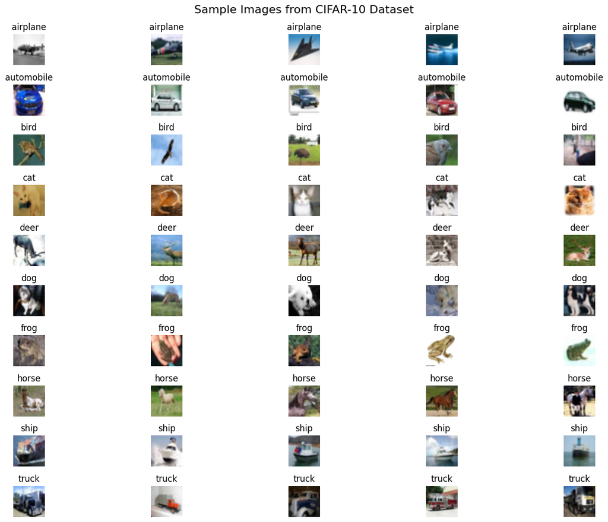

```python
plt.figure(figsize=(15, 10))
for i in range(10):
    # Find indices for each class
    idx = np.where(y_train_full == i)[0]
    # Get 5 random images from each class
    sample_indices = np.random.choice(idx, 5, replace=False)

    for j, sample_idx in enumerate(sample_indices):
        plt.subplot(10, 5, i*5 + j + 1)
        plt.imshow(X_train_full[sample_idx])
        plt.title(f"{class_names[i]}")
        plt.axis('off')

plt.tight_layout()
plt.suptitle("Sample Images from CIFAR-10 Dataset", y=1.02, fontsize=16)
plt.show()
```

## Exploratory Data Analysis (EDA)

### Distribution of Classes

|  | Class | Training Count | Test Count |
| --- | --- | --- | --- |
| 0 | airplane | 5000 | 1000 |
| 1 | automobile | 5000 | 1000 |
| 2 | bird | 5000 | 1000 |
| 3 | cat | 5000 | 1000 |
| 4 | deer | 5000 | 1000 |
| 5 | dog | 5000 | 1000 |
| 6 | frog | 5000 | 1000 |
| 7 | horse | 5000 | 1000 |
| 8 | ship | 5000 | 1000 |
| 9 | truck | 5000 | 1000 |

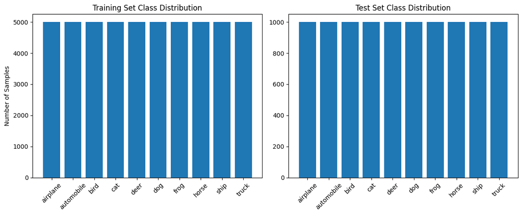

```python
# Count the number of samples in each class
unique_train, counts_train = np.unique(y_train_full, return_counts=True)
unique_test, counts_test = np.unique(y_test, return_counts=True)

# Create a dataframe to display class distribution
distribution_df = pd.DataFrame({
    'Class': [class_names[i] for i in unique_train],
    'Training Count': counts_train,
    'Test Count': counts_test
})
display(distribution_df)

# Plot class distribution
plt.figure(figsize=(12, 5))

plt.subplot(1, 2, 1)
plt.bar([class_names[i] for i in unique_train], counts_train)
plt.title('Training Set Class Distribution')
plt.xticks(rotation=45)
plt.ylabel('Number of Samples')

plt.subplot(1, 2, 2)
plt.bar([class_names[i] for i in unique_test], counts_test)
plt.title('Test Set Class Distribution')
plt.xticks(rotation=45)

plt.tight_layout()
plt.show()
```

**Observations**:

- Both the Train and Test set in totally balanced having same number of images for each 10 classes.

### Pixel Value Distribution

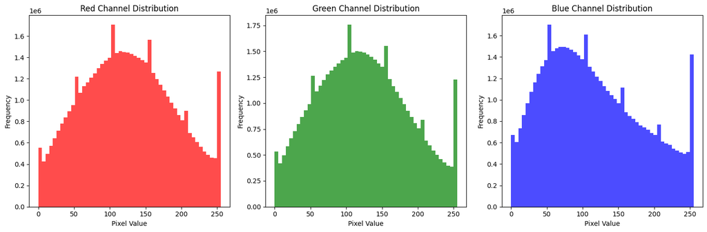

```python
# Let's look at pixel intensity distribution
plt.figure(figsize=(15, 5))

plt.subplot(1, 3, 1)
plt.hist(X_train_full[:, :, :, 0].flatten(), bins=50, color='red', alpha=0.7)
plt.title('Red Channel Distribution')
plt.xlabel('Pixel Value')
plt.ylabel('Frequency')

plt.subplot(1, 3, 2)
plt.hist(X_train_full[:, :, :, 1].flatten(), bins=50, color='green', alpha=0.7)
plt.title('Green Channel Distribution')
plt.xlabel('Pixel Value')
plt.ylabel('Frequency')

plt.subplot(1, 3, 3)
plt.hist(X_train_full[:, :, :, 2].flatten(), bins=50, color='blue', alpha=0.7)
plt.title('Blue Channel Distribution')
plt.xlabel('Pixel Value')
plt.ylabel('Frequency')

plt.tight_layout()
plt.show()
```

### Mean Images of Classes

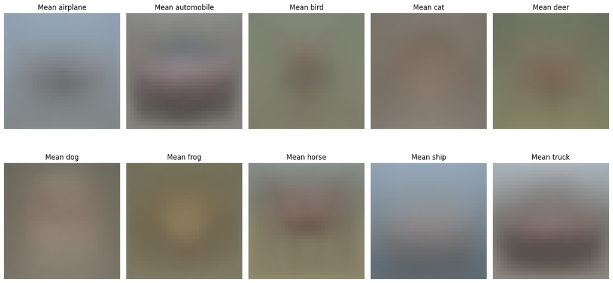

```python
# Calculate mean and standard deviation for each class
class_means = []
class_stds = []

for i in range(10):
    class_images = X_train_full[y_train_full.reshape(-1) == i]
    class_mean = np.mean(class_images, axis=0)
    class_std = np.std(class_images, axis=0)

    class_means.append(class_mean)
    class_stds.append(class_std)

# Display mean images for each class
plt.figure(figsize=(15, 8))
for i in range(10):
    plt.subplot(2, 5, i + 1)
    plt.imshow(class_means[i].astype(int))
    plt.title(f"Mean {class_names[i]}")
    plt.axis('off')
plt.tight_layout()
plt.show()
```

### Pixel Correlation Analysis

```
Correlation between Red and Green channels (first image): 0.9562
Correlation between Red and Blue channels (first image): 0.8439
Correlation between Green and Blue channels (first image): 0.8957
```

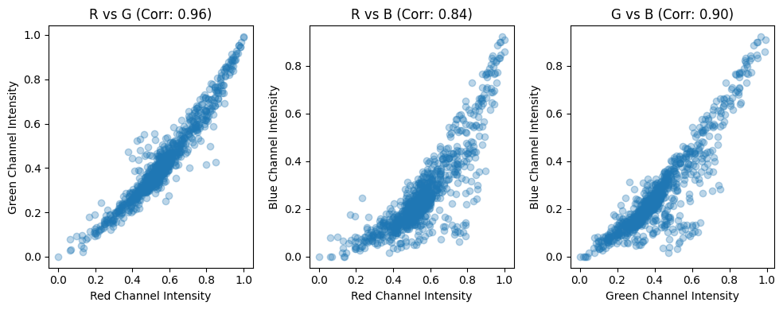

```python
first_image = X_train_full[0] / 255.0  # Normalize to 0-1
red_channel = first_image[:, :, 0].flatten()
green_channel = first_image[:, :, 1].flatten()
blue_channel = first_image[:, :, 2].flatten()

correlation_rg = np.corrcoef(red_channel, green_channel)[0, 1]
correlation_rb = np.corrcoef(red_channel, blue_channel)[0, 1]
correlation_gb = np.corrcoef(green_channel, blue_channel)[0, 1]

print(f"Correlation between Red and Green channels (first image): {correlation_rg:.4f}")
print(f"Correlation between Red and Blue channels (first image): {correlation_rb:.4f}")
print(f"Correlation between Green and Blue channels (first image): {correlation_gb:.4f}")

# Visualize channel correlations for the first image
plt.figure(figsize=(10, 4))

plt.subplot(1, 3, 1)
plt.scatter(red_channel, green_channel, alpha=0.3)
plt.title(f'R vs G (Corr: {correlation_rg:.2f})')
plt.xlabel('Red Channel Intensity')
plt.ylabel('Green Channel Intensity')

plt.subplot(1, 3, 2)
plt.scatter(red_channel, blue_channel, alpha=0.3)
plt.title(f'R vs B (Corr: {correlation_rb:.2f})')
plt.xlabel('Red Channel Intensity')
plt.ylabel('Blue Channel Intensity')

plt.subplot(1, 3, 3)
plt.scatter(green_channel, blue_channel, alpha=0.3)
plt.title(f'G vs B (Corr: {correlation_gb:.2f})')
plt.xlabel('Green Channel Intensity')
plt.ylabel('Blue Channel Intensity')

plt.tight_layout()
plt.show()
```

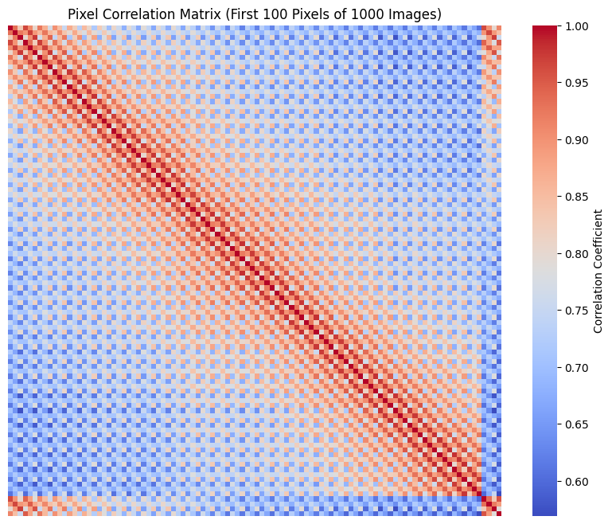

```python
num_samples_corr = 1000  # Analyze a subset for efficiency
subset_images = X_train_full[:num_samples_corr].reshape(num_samples_corr, -1) / 255.0

correlation_matrix = np.corrcoef(subset_images, rowvar=False)

plt.figure(figsize=(10, 8))
sns.heatmap(correlation_matrix[:100, :100], cmap='coolwarm',
            xticklabels=[], yticklabels=[], cbar_kws={'label': 'Correlation Coefficient'})
plt.title(f'Pixel Correlation Matrix (First 100 Pixels of {num_samples_corr} Images)')
plt.show()
```

## Data Preprocessing

### Training Validation Split

```python
# Convert pixel values to float and normalize to range [0, 1]
X_train = X_train_full.astype('float32') / 255.0
X_test = X_test.astype('float32') / 255.0

# Convert class labels to one-hot encoding
y_train_cat = to_categorical(y_train_full, num_classes=10)
y_test_cat = to_categorical(y_test, num_classes=10)

print("Original shape of y_train:", y_train_full.shape)
print("After one-hot encoding:", y_train_cat.shape)

# Split training data to create a validation set
from sklearn.model_selection import train_test_split

X_train, X_val, y_train_cat, y_val_cat = train_test_split(
    X_train, y_train_cat, test_size=0.2, random_state=42
)

print("Training data shape:", X_train.shape)
print("Validation data shape:", X_val.shape)
```

```
Original shape of y_train: (50000, 1)
After one-hot encoding: (50000, 10)
Training data shape: (40000, 32, 32, 3)
Validation data shape: (10000, 32, 32, 3)
```

**Observations**:

- In order for initial model creation, training label data have been split in Training and validation set (20%).
- Training set contains 40000 images and Validatin set contains 10000 images.

### Data Augmentation for Train and Validation set

Data augmentation techniques involve creating new data points from existing ones to increase the size and diversity of a dataset, which can improve model performance and generalization. These techniques are particularly useful when a dataset is limited or not diverse enough to train a robust machine learning model.

### Setup Data Generators for Training set

```python
# Data augmentation for training set
datagen = ImageDataGenerator(
    rotation_range=15,
    width_shift_range=0.1,
    height_shift_range=0.1,
    horizontal_flip=True,
    zoom_range=0.1
)
```

### Visualize Augmented Images

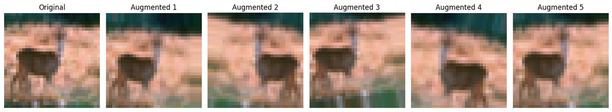

```python
def visualize_augmentation(X, y, datagen, num_images=5):
    # Take a single image and its label
    X_sample = X[0:1]
    y_sample = y[0:1]

    # Generate augmented images
    plt.figure(figsize=(15, 3))
    plt.subplot(1, num_images+1, 1)
    plt.imshow(X_sample[0])
    plt.title("Original")
    plt.axis("off")

    i = 2
    for batch in datagen.flow(X_sample, y_sample, batch_size=1):
        plt.subplot(1, num_images+1, i)
        plt.imshow(batch[0][0])
        plt.title(f"Augmented {i-1}")
        plt.axis("off")
        i += 1
        if i > num_images+1:
            break

    plt.tight_layout()
    plt.show()

# Visualize augmentation on a few random samples
idx = np.random.randint(0, X_train.shape[0])
visualize_augmentation(X_train[idx:idx+1], y_train_cat[idx:idx+1], datagen)
```

## CNN Model Build

### Baseline CNN Model

The baseline CNN model is designed for classifying the CIFAR-10 dataset, which consists of 60,000 32×32 color images across 10 different classes. This model implements a straightforward convolutional neural network architecture that balances simplicity with reasonable performance expectations.

## Convolutional Blocks

**First Convolutional Block**

- 32 convolutional filters with 3×3 kernel size
- ReLU activation function
- 'same' padding to preserve spatial dimensions
- 2×2 max pooling, reducing dimensions to 16×16

**Second Convolutional Block**

- 64 convolutional filters with 3×3 kernel size
- ReLU activation function
- 'same' padding to preserve spatial dimensions
- 2×2 max pooling, reducing dimensions to 8×8

## Classification Layers

**Flatten Layer**

Transforms the 8×8×64 feature maps into a 4,096-dimension vector.

**Dense Hidden Layer**

- 64 neurons with ReLU activation
- Creates a compact representation of extracted features

**Dropout Layer**

- Rate of 0.5 (50% of neurons randomly deactivated during training)
- Prevents overfitting by forcing network redundancy

## Output Layer

**10 neurons (one per CIFAR-10 class)**

Softmax activation for probability distribution across classes

## Model Configuration

**Loss Function:** Categorical crossentropy (standard for multi-class classification)

**Optimizer:** Adam with configurable learning rate (tested at 0.001 and 0.0001)

**Evaluation Metric:** Accuracy

```python
def randomSeedClear():
    # Fixing the seed for random number generators
    np.random.seed(42)
    random.seed(42)
    tf.random.set_seed(42)
    tf.keras.backend.clear_session()
```

#### Model Building

```python
randomSeedClear()

baseline_model = Sequential([
        Conv2D(32, (3, 3), activation='relu', padding='same', input_shape=(32,32,3)),
        MaxPooling2D((2, 2)),

        Conv2D(64, (3, 3), activation='relu', padding='same'),
        MaxPooling2D((2, 2)),

        Flatten(),
        Dense(64, activation='relu'),
        Dropout(0.5),
        Dense(10, activation='softmax')
    ])


baseline_model.compile(
    optimizer='adam',
    loss='categorical_crossentropy',
    metrics=['accuracy']
)

print("Baseline Model Summary:")
baseline_model.summary()
```

```
Baseline Model Summary:
```

[output not shown]

```
Model: "sequential"
```

```
┏━━━━━━━━━━━━━━━━━━━━━━━━━━━━━━━━━┳━━━━━━━━━━━━━━━━━━━━━━━━┳━━━━━━━━━━━━━━━┓
┃ Layer (type)                    ┃ Output Shape           ┃       Param # ┃
┡━━━━━━━━━━━━━━━━━━━━━━━━━━━━━━━━━╇━━━━━━━━━━━━━━━━━━━━━━━━╇━━━━━━━━━━━━━━━┩
│ conv2d (Conv2D)                 │ (None, 32, 32, 32)     │           896 │
├─────────────────────────────────┼────────────────────────┼───────────────┤
│ max_pooling2d (MaxPooling2D)    │ (None, 16, 16, 32)     │             0 │
├─────────────────────────────────┼────────────────────────┼───────────────┤
│ conv2d_1 (Conv2D)               │ (None, 16, 16, 64)     │        18,496 │
├─────────────────────────────────┼────────────────────────┼───────────────┤
│ max_pooling2d_1 (MaxPooling2D)  │ (None, 8, 8, 64)       │             0 │
├─────────────────────────────────┼────────────────────────┼───────────────┤
│ flatten (Flatten)               │ (None, 4096)           │             0 │
├─────────────────────────────────┼────────────────────────┼───────────────┤
│ dense (Dense)                   │ (None, 64)             │       262,208 │
├─────────────────────────────────┼────────────────────────┼───────────────┤
│ dropout (Dropout)               │ (None, 64)             │             0 │
├─────────────────────────────────┼────────────────────────┼───────────────┤
│ dense_1 (Dense)                 │ (None, 10)             │           650 │
└─────────────────────────────────┴────────────────────────┴───────────────┘
```

```
 Total params: 282,250 (1.08 MB)
```

```
 Trainable params: 282,250 (1.08 MB)
```

```
 Non-trainable params: 0 (0.00 B)
```

#### Training Baseline CNN Model

```python
# setting upo checkpoint
checkpoint_baseline = ModelCheckpoint(
    'baseline_model_best.h5',
    monitor='val_accuracy',
    save_best_only=True,
    mode='max',
    verbose=1
)

#setting up early stopping
early_stopping = EarlyStopping(
    monitor='val_accuracy',
    patience=10,
    restore_best_weights=True,
    verbose=1
)

# setting up reduce_lr
reduce_lr = ReduceLROnPlateau(
    monitor='val_loss',
    factor=0.2,
    patience=5,
    min_lr=1e-6,
    verbose=1
)

# Running Training
history_base = baseline_model.fit(
    datagen.flow(X_train, y_train_cat, batch_size=64),
    steps_per_epoch=len(X_train) // 64,
    validation_data=(X_val, y_val_cat),
    epochs=50,
    callbacks=[checkpoint_baseline, early_stopping, reduce_lr],
    verbose=1
)
```

```
2025-05-18 17:31:08.260430: I tensorflow/core/grappler/optimizers/custom_graph_optimizer_registry.cc:117] Plugin optimizer for device_type GPU is enabled.
```

```
623/625 ━━━━━━━━━━━━━━━━━━━━ 0s 14ms/step - accuracy: 0.2309 - loss: 2.0621
Epoch 1: val_accuracy improved from -inf to 0.46840, saving model to baseline_model_best.h5
```

```
WARNING:absl:You are saving your model as an HDF5 file via `model.save()` or `keras.saving.save_model(model)`. This file format is considered legacy. We recommend using instead the native Keras format, e.g. `model.save('my_model.keras')` or `keras.saving.save_model(model, 'my_model.keras')`.
```

```
625/625 ━━━━━━━━━━━━━━━━━━━━ 11s 17ms/step - accuracy: 0.2312 - loss: 2.0613 - val_accuracy: 0.4684 - val_loss: 1.5025 - learning_rate: 0.0010
625/625 ━━━━━━━━━━━━━━━━━━━━ 0s 14ms/step - accuracy: 0.3838 - loss: 1.7032
Epoch 2: val_accuracy improved from 0.46840 to 0.53950, saving model to baseline_model_best.h5
```

```
WARNING:absl:You are saving your model as an HDF5 file via `model.save()` or `keras.saving.save_model(model)`. This file format is considered legacy. We recommend using instead the native Keras format, e.g. `model.save('my_model.keras')` or `keras.saving.save_model(model, 'my_model.keras')`.
```

```
625/625 ━━━━━━━━━━━━━━━━━━━━ 10s 17ms/step - accuracy: 0.3838 - loss: 1.7032 - val_accuracy: 0.5395 - val_loss: 1.3108 - learning_rate: 0.0010
623/625 ━━━━━━━━━━━━━━━━━━━━ 0s 14ms/step - accuracy: 0.4384 - loss: 1.5619
Epoch 3: val_accuracy improved from 0.53950 to 0.55710, saving model to baseline_model_best.h5
```

```
WARNING:absl:You are saving your model as an HDF5 file via `model.save()` or `keras.saving.save_model(model)`. This file format is considered legacy. We recommend using instead the native Keras format, e.g. `model.save('my_model.keras')` or `keras.saving.save_model(model, 'my_model.keras')`.
```

```
625/625 ━━━━━━━━━━━━━━━━━━━━ 10s 16ms/step - accuracy: 0.4384 - loss: 1.5618 - val_accuracy: 0.5571 - val_loss: 1.2538 - learning_rate: 0.0010
623/625 ━━━━━━━━━━━━━━━━━━━━ 0s 13ms/step - accuracy: 0.4678 - loss: 1.4923
Epoch 4: val_accuracy improved from 0.55710 to 0.57080, saving model to baseline_model_best.h5
```

```
WARNING:absl:You are saving your model as an HDF5 file via `model.save()` or `keras.saving.save_model(model)`. This file format is considered legacy. We recommend using instead the native Keras format, e.g. `model.save('my_model.keras')` or `keras.saving.save_model(model, 'my_model.keras')`.
```

```
625/625 ━━━━━━━━━━━━━━━━━━━━ 10s 16ms/step - accuracy: 0.4678 - loss: 1.4922 - val_accuracy: 0.5708 - val_loss: 1.1771 - learning_rate: 0.0010
623/625 ━━━━━━━━━━━━━━━━━━━━ 0s 14ms/step - accuracy: 0.4749 - loss: 1.4646
Epoch 5: val_accuracy improved from 0.57080 to 0.58780, saving model to baseline_model_best.h5
```

```
WARNING:absl:You are saving your model as an HDF5 file via `model.save()` or `keras.saving.save_model(model)`. This file format is considered legacy. We recommend using instead the native Keras format, e.g. `model.save('my_model.keras')` or `keras.saving.save_model(model, 'my_model.keras')`.
```

```
625/625 ━━━━━━━━━━━━━━━━━━━━ 11s 17ms/step - accuracy: 0.4749 - loss: 1.4645 - val_accuracy: 0.5878 - val_loss: 1.1492 - learning_rate: 0.0010
623/625 ━━━━━━━━━━━━━━━━━━━━ 0s 17ms/step - accuracy: 0.4946 - loss: 1.4239
Epoch 6: val_accuracy improved from 0.58780 to 0.59440, saving model to baseline_model_best.h5
```

```
WARNING:absl:You are saving your model as an HDF5 file via `model.save()` or `keras.saving.save_model(model)`. This file format is considered legacy. We recommend using instead the native Keras format, e.g. `model.save('my_model.keras')` or `keras.saving.save_model(model, 'my_model.keras')`.
```

```
625/625 ━━━━━━━━━━━━━━━━━━━━ 12s 19ms/step - accuracy: 0.4946 - loss: 1.4239 - val_accuracy: 0.5944 - val_loss: 1.1260 - learning_rate: 0.0010
622/625 ━━━━━━━━━━━━━━━━━━━━ 0s 14ms/step - accuracy: 0.5043 - loss: 1.4026
Epoch 7: val_accuracy improved from 0.59440 to 0.59450, saving model to baseline_model_best.h5
```

```
WARNING:absl:You are saving your model as an HDF5 file via `model.save()` or `keras.saving.save_model(model)`. This file format is considered legacy. We recommend using instead the native Keras format, e.g. `model.save('my_model.keras')` or `keras.saving.save_model(model, 'my_model.keras')`.
```

```
625/625 ━━━━━━━━━━━━━━━━━━━━ 10s 16ms/step - accuracy: 0.5043 - loss: 1.4026 - val_accuracy: 0.5945 - val_loss: 1.1183 - learning_rate: 0.0010
625/625 ━━━━━━━━━━━━━━━━━━━━ 0s 14ms/step - accuracy: 0.5123 - loss: 1.3877
Epoch 8: val_accuracy improved from 0.59450 to 0.61020, saving model to baseline_model_best.h5
```

```
WARNING:absl:You are saving your model as an HDF5 file via `model.save()` or `keras.saving.save_model(model)`. This file format is considered legacy. We recommend using instead the native Keras format, e.g. `model.save('my_model.keras')` or `keras.saving.save_model(model, 'my_model.keras')`.
```

```
625/625 ━━━━━━━━━━━━━━━━━━━━ 11s 17ms/step - accuracy: 0.5123 - loss: 1.3877 - val_accuracy: 0.6102 - val_loss: 1.1018 - learning_rate: 0.0010
623/625 ━━━━━━━━━━━━━━━━━━━━ 0s 14ms/step - accuracy: 0.5131 - loss: 1.3708
Epoch 9: val_accuracy improved from 0.61020 to 0.62150, saving model to baseline_model_best.h5
```

```
WARNING:absl:You are saving your model as an HDF5 file via `model.save()` or `keras.saving.save_model(model)`. This file format is considered legacy. We recommend using instead the native Keras format, e.g. `model.save('my_model.keras')` or `keras.saving.save_model(model, 'my_model.keras')`.
```

```
625/625 ━━━━━━━━━━━━━━━━━━━━ 10s 17ms/step - accuracy: 0.5132 - loss: 1.3707 - val_accuracy: 0.6215 - val_loss: 1.0648 - learning_rate: 0.0010
623/625 ━━━━━━━━━━━━━━━━━━━━ 0s 14ms/step - accuracy: 0.5240 - loss: 1.3503
Epoch 10: val_accuracy did not improve from 0.62150
625/625 ━━━━━━━━━━━━━━━━━━━━ 11s 17ms/step - accuracy: 0.5240 - loss: 1.3503 - val_accuracy: 0.6086 - val_loss: 1.1094 - learning_rate: 0.0010
625/625 ━━━━━━━━━━━━━━━━━━━━ 0s 14ms/step - accuracy: 0.5214 - loss: 1.3652
Epoch 11: val_accuracy did not improve from 0.62150
625/625 ━━━━━━━━━━━━━━━━━━━━ 10s 17ms/step - accuracy: 0.5214 - loss: 1.3652 - val_accuracy: 0.5870 - val_loss: 1.1398 - learning_rate: 0.0010
623/625 ━━━━━━━━━━━━━━━━━━━━ 0s 14ms/step - accuracy: 0.5234 - loss: 1.3480
Epoch 12: val_accuracy did not improve from 0.62150
625/625 ━━━━━━━━━━━━━━━━━━━━ 10s 16ms/step - accuracy: 0.5234 - loss: 1.3480 - val_accuracy: 0.5909 - val_loss: 1.1551 - learning_rate: 0.0010
622/625 ━━━━━━━━━━━━━━━━━━━━ 0s 14ms/step - accuracy: 0.5229 - loss: 1.3551
Epoch 13: val_accuracy improved from 0.62150 to 0.63050, saving model to baseline_model_best.h5
```

```
WARNING:absl:You are saving your model as an HDF5 file via `model.save()` or `keras.saving.save_model(model)`. This file format is considered legacy. We recommend using instead the native Keras format, e.g. `model.save('my_model.keras')` or `keras.saving.save_model(model, 'my_model.keras')`.
```

```
625/625 ━━━━━━━━━━━━━━━━━━━━ 11s 17ms/step - accuracy: 0.5229 - loss: 1.3550 - val_accuracy: 0.6305 - val_loss: 1.0592 - learning_rate: 0.0010
625/625 ━━━━━━━━━━━━━━━━━━━━ 0s 14ms/step - accuracy: 0.5276 - loss: 1.3474
Epoch 14: val_accuracy did not improve from 0.63050
625/625 ━━━━━━━━━━━━━━━━━━━━ 10s 17ms/step - accuracy: 0.5276 - loss: 1.3474 - val_accuracy: 0.6290 - val_loss: 1.0389 - learning_rate: 0.0010
623/625 ━━━━━━━━━━━━━━━━━━━━ 0s 14ms/step - accuracy: 0.5297 - loss: 1.3332
Epoch 15: val_accuracy did not improve from 0.63050
625/625 ━━━━━━━━━━━━━━━━━━━━ 10s 16ms/step - accuracy: 0.5297 - loss: 1.3333 - val_accuracy: 0.6286 - val_loss: 1.0460 - learning_rate: 0.0010
622/625 ━━━━━━━━━━━━━━━━━━━━ 0s 11ms/step - accuracy: 0.5279 - loss: 1.3497
Epoch 16: val_accuracy improved from 0.63050 to 0.65040, saving model to baseline_model_best.h5
```

```
WARNING:absl:You are saving your model as an HDF5 file via `model.save()` or `keras.saving.save_model(model)`. This file format is considered legacy. We recommend using instead the native Keras format, e.g. `model.save('my_model.keras')` or `keras.saving.save_model(model, 'my_model.keras')`.
```

```
625/625 ━━━━━━━━━━━━━━━━━━━━ 8s 13ms/step - accuracy: 0.5279 - loss: 1.3497 - val_accuracy: 0.6504 - val_loss: 0.9838 - learning_rate: 0.0010
623/625 ━━━━━━━━━━━━━━━━━━━━ 0s 10ms/step - accuracy: 0.5325 - loss: 1.3446
Epoch 17: val_accuracy did not improve from 0.65040
625/625 ━━━━━━━━━━━━━━━━━━━━ 7s 12ms/step - accuracy: 0.5325 - loss: 1.3446 - val_accuracy: 0.6480 - val_loss: 1.0034 - learning_rate: 0.0010
625/625 ━━━━━━━━━━━━━━━━━━━━ 0s 10ms/step - accuracy: 0.5367 - loss: 1.3310
Epoch 18: val_accuracy did not improve from 0.65040
625/625 ━━━━━━━━━━━━━━━━━━━━ 7s 12ms/step - accuracy: 0.5367 - loss: 1.3310 - val_accuracy: 0.6413 - val_loss: 1.0368 - learning_rate: 0.0010
623/625 ━━━━━━━━━━━━━━━━━━━━ 0s 10ms/step - accuracy: 0.5323 - loss: 1.3466
Epoch 19: val_accuracy did not improve from 0.65040
625/625 ━━━━━━━━━━━━━━━━━━━━ 8s 12ms/step - accuracy: 0.5323 - loss: 1.3465 - val_accuracy: 0.6192 - val_loss: 1.0743 - learning_rate: 0.0010
625/625 ━━━━━━━━━━━━━━━━━━━━ 0s 10ms/step - accuracy: 0.5393 - loss: 1.3193
Epoch 20: val_accuracy did not improve from 0.65040
625/625 ━━━━━━━━━━━━━━━━━━━━ 8s 12ms/step - accuracy: 0.5393 - loss: 1.3193 - val_accuracy: 0.6242 - val_loss: 1.0509 - learning_rate: 0.0010
620/625 ━━━━━━━━━━━━━━━━━━━━ 0s 10ms/step - accuracy: 0.5327 - loss: 1.3514
Epoch 21: val_accuracy did not improve from 0.65040

Epoch 21: ReduceLROnPlateau reducing learning rate to 0.00020000000949949026.
625/625 ━━━━━━━━━━━━━━━━━━━━ 7s 12ms/step - accuracy: 0.5327 - loss: 1.3515 - val_accuracy: 0.6499 - val_loss: 0.9919 - learning_rate: 0.0010
622/625 ━━━━━━━━━━━━━━━━━━━━ 0s 10ms/step - accuracy: 0.5650 - loss: 1.2491
Epoch 22: val_accuracy improved from 0.65040 to 0.66750, saving model to baseline_model_best.h5
```

```
WARNING:absl:You are saving your model as an HDF5 file via `model.save()` or `keras.saving.save_model(model)`. This file format is considered legacy. We recommend using instead the native Keras format, e.g. `model.save('my_model.keras')` or `keras.saving.save_model(model, 'my_model.keras')`.
```

```
625/625 ━━━━━━━━━━━━━━━━━━━━ 8s 12ms/step - accuracy: 0.5651 - loss: 1.2490 - val_accuracy: 0.6675 - val_loss: 0.9417 - learning_rate: 2.0000e-04
622/625 ━━━━━━━━━━━━━━━━━━━━ 0s 10ms/step - accuracy: 0.5778 - loss: 1.2154
Epoch 23: val_accuracy improved from 0.66750 to 0.67820, saving model to baseline_model_best.h5
```

```
WARNING:absl:You are saving your model as an HDF5 file via `model.save()` or `keras.saving.save_model(model)`. This file format is considered legacy. We recommend using instead the native Keras format, e.g. `model.save('my_model.keras')` or `keras.saving.save_model(model, 'my_model.keras')`.
```

```
625/625 ━━━━━━━━━━━━━━━━━━━━ 8s 12ms/step - accuracy: 0.5778 - loss: 1.2154 - val_accuracy: 0.6782 - val_loss: 0.9412 - learning_rate: 2.0000e-04
623/625 ━━━━━━━━━━━━━━━━━━━━ 0s 10ms/step - accuracy: 0.5803 - loss: 1.2022
Epoch 24: val_accuracy did not improve from 0.67820
625/625 ━━━━━━━━━━━━━━━━━━━━ 8s 12ms/step - accuracy: 0.5803 - loss: 1.2022 - val_accuracy: 0.6771 - val_loss: 0.9342 - learning_rate: 2.0000e-04
623/625 ━━━━━━━━━━━━━━━━━━━━ 0s 10ms/step - accuracy: 0.5797 - loss: 1.1979
Epoch 25: val_accuracy improved from 0.67820 to 0.67920, saving model to baseline_model_best.h5
```

```
WARNING:absl:You are saving your model as an HDF5 file via `model.save()` or `keras.saving.save_model(model)`. This file format is considered legacy. We recommend using instead the native Keras format, e.g. `model.save('my_model.keras')` or `keras.saving.save_model(model, 'my_model.keras')`.
```

```
625/625 ━━━━━━━━━━━━━━━━━━━━ 8s 12ms/step - accuracy: 0.5797 - loss: 1.1979 - val_accuracy: 0.6792 - val_loss: 0.9345 - learning_rate: 2.0000e-04
620/625 ━━━━━━━━━━━━━━━━━━━━ 0s 10ms/step - accuracy: 0.5795 - loss: 1.2079
Epoch 26: val_accuracy improved from 0.67920 to 0.68800, saving model to baseline_model_best.h5
```

```
WARNING:absl:You are saving your model as an HDF5 file via `model.save()` or `keras.saving.save_model(model)`. This file format is considered legacy. We recommend using instead the native Keras format, e.g. `model.save('my_model.keras')` or `keras.saving.save_model(model, 'my_model.keras')`.
```

```
625/625 ━━━━━━━━━━━━━━━━━━━━ 8s 12ms/step - accuracy: 0.5795 - loss: 1.2080 - val_accuracy: 0.6880 - val_loss: 0.9137 - learning_rate: 2.0000e-04
624/625 ━━━━━━━━━━━━━━━━━━━━ 0s 10ms/step - accuracy: 0.5785 - loss: 1.2120
Epoch 27: val_accuracy did not improve from 0.68800
625/625 ━━━━━━━━━━━━━━━━━━━━ 8s 12ms/step - accuracy: 0.5785 - loss: 1.2120 - val_accuracy: 0.6780 - val_loss: 0.9307 - learning_rate: 2.0000e-04
623/625 ━━━━━━━━━━━━━━━━━━━━ 0s 10ms/step - accuracy: 0.5789 - loss: 1.2060
Epoch 28: val_accuracy did not improve from 0.68800
625/625 ━━━━━━━━━━━━━━━━━━━━ 7s 12ms/step - accuracy: 0.5789 - loss: 1.2060 - val_accuracy: 0.6823 - val_loss: 0.9273 - learning_rate: 2.0000e-04
621/625 ━━━━━━━━━━━━━━━━━━━━ 0s 10ms/step - accuracy: 0.5749 - loss: 1.2149
Epoch 29: val_accuracy did not improve from 0.68800
625/625 ━━━━━━━━━━━━━━━━━━━━ 8s 12ms/step - accuracy: 0.5750 - loss: 1.2148 - val_accuracy: 0.6734 - val_loss: 0.9565 - learning_rate: 2.0000e-04
625/625 ━━━━━━━━━━━━━━━━━━━━ 0s 10ms/step - accuracy: 0.5790 - loss: 1.2086
Epoch 30: val_accuracy did not improve from 0.68800
625/625 ━━━━━━━━━━━━━━━━━━━━ 8s 12ms/step - accuracy: 0.5790 - loss: 1.2086 - val_accuracy: 0.6770 - val_loss: 0.9390 - learning_rate: 2.0000e-04
621/625 ━━━━━━━━━━━━━━━━━━━━ 0s 10ms/step - accuracy: 0.5825 - loss: 1.2049
Epoch 31: val_accuracy did not improve from 0.68800

Epoch 31: ReduceLROnPlateau reducing learning rate to 4.0000001899898055e-05.
625/625 ━━━━━━━━━━━━━━━━━━━━ 8s 12ms/step - accuracy: 0.5825 - loss: 1.2049 - val_accuracy: 0.6695 - val_loss: 0.9557 - learning_rate: 2.0000e-04
624/625 ━━━━━━━━━━━━━━━━━━━━ 0s 10ms/step - accuracy: 0.5865 - loss: 1.1869
Epoch 32: val_accuracy did not improve from 0.68800
625/625 ━━━━━━━━━━━━━━━━━━━━ 8s 12ms/step - accuracy: 0.5865 - loss: 1.1868 - val_accuracy: 0.6822 - val_loss: 0.9285 - learning_rate: 4.0000e-05
624/625 ━━━━━━━━━━━━━━━━━━━━ 0s 10ms/step - accuracy: 0.5894 - loss: 1.1864
Epoch 33: val_accuracy did not improve from 0.68800
625/625 ━━━━━━━━━━━━━━━━━━━━ 8s 12ms/step - accuracy: 0.5894 - loss: 1.1864 - val_accuracy: 0.6804 - val_loss: 0.9306 - learning_rate: 4.0000e-05
622/625 ━━━━━━━━━━━━━━━━━━━━ 0s 10ms/step - accuracy: 0.5900 - loss: 1.1899
Epoch 34: val_accuracy did not improve from 0.68800
625/625 ━━━━━━━━━━━━━━━━━━━━ 8s 12ms/step - accuracy: 0.5900 - loss: 1.1898 - val_accuracy: 0.6828 - val_loss: 0.9231 - learning_rate: 4.0000e-05
620/625 ━━━━━━━━━━━━━━━━━━━━ 0s 10ms/step - accuracy: 0.5968 - loss: 1.1725
Epoch 35: val_accuracy did not improve from 0.68800
625/625 ━━━━━━━━━━━━━━━━━━━━ 8s 12ms/step - accuracy: 0.5968 - loss: 1.1726 - val_accuracy: 0.6764 - val_loss: 0.9351 - learning_rate: 4.0000e-05
624/625 ━━━━━━━━━━━━━━━━━━━━ 0s 10ms/step - accuracy: 0.5958 - loss: 1.1736
Epoch 36: val_accuracy improved from 0.68800 to 0.68820, saving model to baseline_model_best.h5
```

```
WARNING:absl:You are saving your model as an HDF5 file via `model.save()` or `keras.saving.save_model(model)`. This file format is considered legacy. We recommend using instead the native Keras format, e.g. `model.save('my_model.keras')` or `keras.saving.save_model(model, 'my_model.keras')`.
```

```
Epoch 36: ReduceLROnPlateau reducing learning rate to 8.000000525498762e-06.
625/625 ━━━━━━━━━━━━━━━━━━━━ 8s 12ms/step - accuracy: 0.5958 - loss: 1.1737 - val_accuracy: 0.6882 - val_loss: 0.9152 - learning_rate: 4.0000e-05
624/625 ━━━━━━━━━━━━━━━━━━━━ 0s 10ms/step - accuracy: 0.6029 - loss: 1.1655
Epoch 37: val_accuracy improved from 0.68820 to 0.68860, saving model to baseline_model_best.h5
```

```
WARNING:absl:You are saving your model as an HDF5 file via `model.save()` or `keras.saving.save_model(model)`. This file format is considered legacy. We recommend using instead the native Keras format, e.g. `model.save('my_model.keras')` or `keras.saving.save_model(model, 'my_model.keras')`.
```

```
625/625 ━━━━━━━━━━━━━━━━━━━━ 8s 12ms/step - accuracy: 0.6029 - loss: 1.1655 - val_accuracy: 0.6886 - val_loss: 0.9138 - learning_rate: 8.0000e-06
625/625 ━━━━━━━━━━━━━━━━━━━━ 0s 10ms/step - accuracy: 0.5968 - loss: 1.1746
Epoch 38: val_accuracy did not improve from 0.68860
625/625 ━━━━━━━━━━━━━━━━━━━━ 8s 12ms/step - accuracy: 0.5968 - loss: 1.1746 - val_accuracy: 0.6857 - val_loss: 0.9157 - learning_rate: 8.0000e-06
623/625 ━━━━━━━━━━━━━━━━━━━━ 0s 10ms/step - accuracy: 0.5996 - loss: 1.1668
Epoch 39: val_accuracy did not improve from 0.68860
625/625 ━━━━━━━━━━━━━━━━━━━━ 8s 12ms/step - accuracy: 0.5996 - loss: 1.1668 - val_accuracy: 0.6858 - val_loss: 0.9181 - learning_rate: 8.0000e-06
625/625 ━━━━━━━━━━━━━━━━━━━━ 0s 10ms/step - accuracy: 0.6005 - loss: 1.1626
Epoch 40: val_accuracy did not improve from 0.68860
625/625 ━━━━━━━━━━━━━━━━━━━━ 8s 12ms/step - accuracy: 0.6005 - loss: 1.1626 - val_accuracy: 0.6858 - val_loss: 0.9172 - learning_rate: 8.0000e-06
625/625 ━━━━━━━━━━━━━━━━━━━━ 0s 10ms/step - accuracy: 0.6003 - loss: 1.1733
Epoch 41: val_accuracy did not improve from 0.68860

Epoch 41: ReduceLROnPlateau reducing learning rate to 1.6000001778593287e-06.
625/625 ━━━━━━━━━━━━━━━━━━━━ 8s 12ms/step - accuracy: 0.6003 - loss: 1.1733 - val_accuracy: 0.6862 - val_loss: 0.9184 - learning_rate: 8.0000e-06
620/625 ━━━━━━━━━━━━━━━━━━━━ 0s 10ms/step - accuracy: 0.5934 - loss: 1.1789
Epoch 42: val_accuracy did not improve from 0.68860
625/625 ━━━━━━━━━━━━━━━━━━━━ 8s 12ms/step - accuracy: 0.5934 - loss: 1.1789 - val_accuracy: 0.6877 - val_loss: 0.9163 - learning_rate: 1.6000e-06
621/625 ━━━━━━━━━━━━━━━━━━━━ 0s 10ms/step - accuracy: 0.5936 - loss: 1.1754
Epoch 43: val_accuracy did not improve from 0.68860
625/625 ━━━━━━━━━━━━━━━━━━━━ 8s 13ms/step - accuracy: 0.5936 - loss: 1.1754 - val_accuracy: 0.6866 - val_loss: 0.9181 - learning_rate: 1.6000e-06
623/625 ━━━━━━━━━━━━━━━━━━━━ 0s 10ms/step - accuracy: 0.5903 - loss: 1.1798
Epoch 44: val_accuracy did not improve from 0.68860
625/625 ━━━━━━━━━━━━━━━━━━━━ 8s 12ms/step - accuracy: 0.5904 - loss: 1.1798 - val_accuracy: 0.6876 - val_loss: 0.9147 - learning_rate: 1.6000e-06
621/625 ━━━━━━━━━━━━━━━━━━━━ 0s 10ms/step - accuracy: 0.5986 - loss: 1.1743
Epoch 45: val_accuracy did not improve from 0.68860
625/625 ━━━━━━━━━━━━━━━━━━━━ 8s 12ms/step - accuracy: 0.5986 - loss: 1.1743 - val_accuracy: 0.6875 - val_loss: 0.9162 - learning_rate: 1.6000e-06
620/625 ━━━━━━━━━━━━━━━━━━━━ 0s 10ms/step - accuracy: 0.5982 - loss: 1.1713
Epoch 46: val_accuracy did not improve from 0.68860

Epoch 46: ReduceLROnPlateau reducing learning rate to 1e-06.
625/625 ━━━━━━━━━━━━━━━━━━━━ 8s 12ms/step - accuracy: 0.5982 - loss: 1.1713 - val_accuracy: 0.6880 - val_loss: 0.9144 - learning_rate: 1.6000e-06
620/625 ━━━━━━━━━━━━━━━━━━━━ 0s 10ms/step - accuracy: 0.5934 - loss: 1.1734
Epoch 47: val_accuracy did not improve from 0.68860
625/625 ━━━━━━━━━━━━━━━━━━━━ 8s 12ms/step - accuracy: 0.5934 - loss: 1.1734 - val_accuracy: 0.6876 - val_loss: 0.9155 - learning_rate: 1.0000e-06
Epoch 47: early stopping
Restoring model weights from the end of the best epoch: 37.
```

#### Visualizing Training History

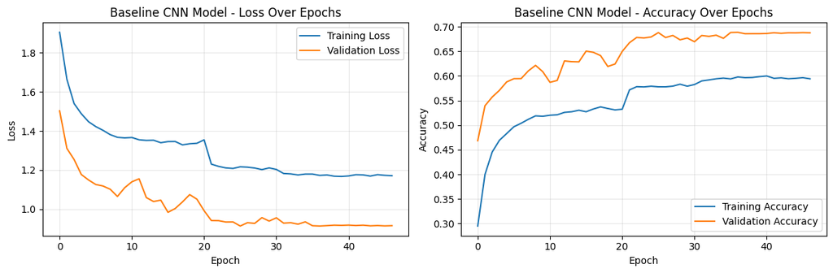

```
Best epoch: 26
Best validation loss: 0.9137
Corresponding validation accuracy: 0.6880
```

```python
model_name="Baseline CNN Model"

# Get metrics
metrics = history_base.history

# Plot training curves
plt.figure(figsize=(12, 4))

# Plot loss
plt.subplot(1,2,1)
plt.plot(metrics['loss'], label='Training Loss')
plt.plot(metrics['val_loss'], label='Validation Loss')
plt.title(f'{model_name} - Loss Over Epochs')
plt.xlabel('Epoch')
plt.ylabel('Loss')
plt.legend()
plt.grid(True, alpha=0.3)

# Plot accuracy
plt.subplot(1,2,2)
plt.plot(metrics['accuracy'], label='Training Accuracy')
plt.plot(metrics['val_accuracy'], label='Validation Accuracy')
plt.title(f'{model_name} - Accuracy Over Epochs')
plt.xlabel('Epoch')
plt.ylabel('Accuracy')
plt.legend()
plt.grid(True, alpha=0.3)

plt.tight_layout()
plt.show()

# Find best epoch
best_epoch = np.argmin(metrics['val_loss'])
print(f"\nBest epoch: {best_epoch+1}")
print(f"Best validation loss: {metrics['val_loss'][best_epoch]:.4f}")
print(f"Corresponding validation accuracy: {metrics['val_accuracy'][best_epoch]:.4f}")
```

### Baseline CNN Model Prediction on Validation Set

```python
y_pred_base = baseline_model.predict(X_val)
y_pred_base_classes = np.argmax(y_pred_base, axis=1)
y_true_classes = np.argmax(y_val_cat, axis=1)
```

```
313/313 ━━━━━━━━━━━━━━━━━━━━ 0s 1ms/step
```

### Baseline CNN Model Prediction Metrics

```python
# Compute metrics
baseline_accuracy = accuracy_score(y_true_classes, y_pred_base_classes)
baseline_precision = precision_score(y_true_classes, y_pred_base_classes,average='weighted')
baseline_recall = recall_score(y_true_classes, y_pred_base_classes,average='weighted')
baseline_f1 = f1_score(y_true_classes, y_pred_base_classes,average='weighted')

print(f"Baseline CNN Model - Evaluation Metrics:")
print(f"Accuracy: {baseline_accuracy:.4f}")
print(f"Precision: {baseline_precision:.4f}")
print(f"Recall: {baseline_recall:.4f}")
print(f"F1 Score: {baseline_f1:.4f}")
```

```
Baseline CNN Model - Evaluation Metrics:
Accuracy: 0.6886
Precision: 0.6878
Recall: 0.6886
F1 Score: 0.6786
```

### Baseline CNN Model Confusion Metrix

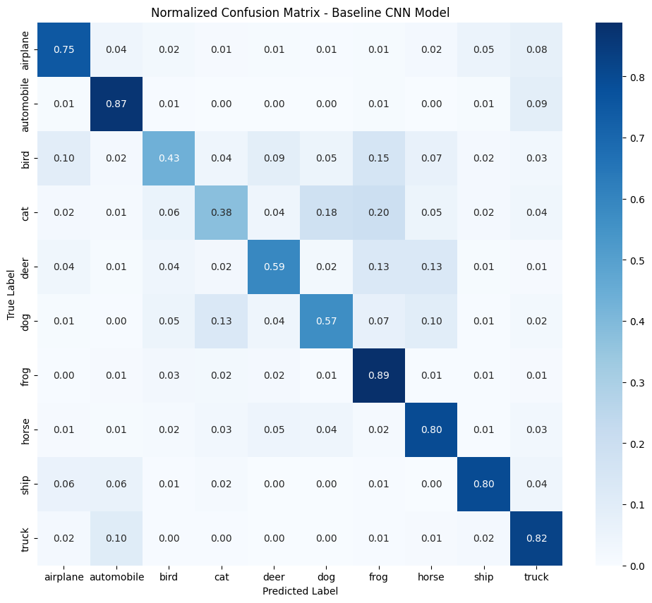

```python
# Compute confusion matrix
cm = confusion_matrix(y_true_classes, y_pred_base_classes)
cm_norm = cm.astype('float') / cm.sum(axis=1)[:, np.newaxis]

# Plot the confusion matrix
plt.figure(figsize=(12, 10))
sns.heatmap(cm_norm, annot=True, fmt='.2f', cmap='Blues',
            xticklabels=class_names, yticklabels=class_names)
plt.title('Normalized Confusion Matrix - Baseline CNN Model')
plt.ylabel('True Label')
plt.xlabel('Predicted Label')
plt.show()
```

### Baseline CNN Model Visualizing Predictions

```
Baseline CNN Model Predictions:
1/1 ━━━━━━━━━━━━━━━━━━━━ 0s 21ms/step
```

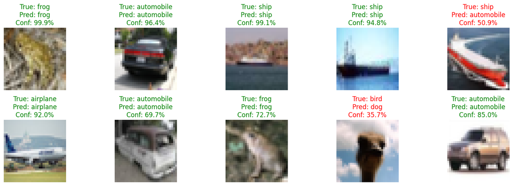

```python
def display_predictions(model, X, y_true, class_names, num_images=10):
    # Get random samples
    indices = np.random.choice(range(len(X)), size=num_images, replace=False)
    X_sample = X[indices]
    y_true_sample = y_true[indices]

    # Make predictions
    predictions = model.predict(X_sample)
    y_pred = np.argmax(predictions, axis=1)

    # Display images and predictions
    plt.figure(figsize=(15, 5))
    for i in range(num_images):
        plt.subplot(2, 5, i+1)
        plt.imshow(X_sample[i])

        true_class = class_names[np.argmax(y_true_sample[i])]
        pred_class = class_names[y_pred[i]]
        confidence = predictions[i][y_pred[i]] * 100

        title_color = 'green' if true_class == pred_class else 'red'
        plt.title(f"True: {true_class}\nPred: {pred_class}\nConf: {confidence:.1f}%",
                 color=title_color)
        plt.axis('off')

    plt.tight_layout()
    plt.show()

# Visualize predictions from the baseline model
print("Baseline CNN Model Predictions:")
display_predictions(baseline_model, X_val, y_val_cat, class_names)
```

### Analysis Misclassified Samples

```
Baseline CNN Model Misclassification Analysis:
313/313 ━━━━━━━━━━━━━━━━━━━━ 0s 1ms/step
```

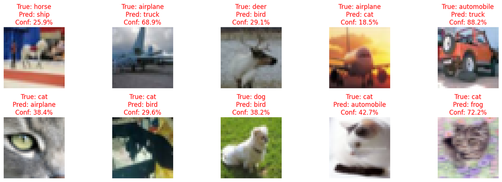

```
Top Misclassification Patterns:
  cat → frog: 202 instances
  cat → dog: 187 instances
  bird → frog: 159 instances
  dog → cat: 131 instances
  deer → frog: 123 instances
```

```python
def analyze_misclassifications(model, X, y_true_one_hot, class_names):
    # Make predictions
    y_pred = model.predict(X)
    y_pred_classes = np.argmax(y_pred, axis=1)
    y_true_classes = np.argmax(y_true_one_hot, axis=1)

    # Find misclassified samples
    misclassified_indices = np.where(y_pred_classes != y_true_classes)[0]

    if len(misclassified_indices) == 0:
        print("No misclassifications found.")
        return

    # Select a subset of misclassifications to analyze
    subset_size = min(10, len(misclassified_indices))
    selected_indices = np.random.choice(misclassified_indices, size=subset_size, replace=False)

    # Display misclassified images
    plt.figure(figsize=(15, 5))
    for i, idx in enumerate(selected_indices):
        plt.subplot(2, 5, i+1)
        plt.imshow(X[idx])

        true_class = class_names[y_true_classes[idx]]
        pred_class = class_names[y_pred_classes[idx]]
        confidence = y_pred[idx][y_pred_classes[idx]] * 100

        plt.title(f"True: {true_class}\nPred: {pred_class}\nConf: {confidence:.1f}%", color='red')
        plt.axis('off')

    plt.tight_layout()
    plt.show()

    # Analyze common misclassification patterns
    cm = confusion_matrix(y_true_classes, y_pred_classes)
    np.fill_diagonal(cm, 0)  # Zero out the diagonal to focus on errors

    # Find the top misclassification pairs
    highest_errors = []
    for i in range(len(class_names)):
        for j in range(len(class_names)):
            if i != j:
                highest_errors.append((i, j, cm[i, j]))

    highest_errors.sort(key=lambda x: x[2], reverse=True)

    print("Top Misclassification Patterns:")
    for true_idx, pred_idx, count in highest_errors[:5]:
        print(f"  {class_names[true_idx]} → {class_names[pred_idx]}: {count} instances")

# Analyze misclassifications for the model
print("Baseline CNN Model Misclassification Analysis:")
analyze_misclassifications(baseline_model, X_val, y_val_cat, class_names)
```

## Hyper-parameter Tuning on Baseline CNN Model

Baseline CNN Model is evaluated with below hyperparameter combinations—

- Learning rates: 0.001 and 0.0001
- Batch sizes: 64 and 128
- Dropout rates: 0.25 and 0.5

```python
randomSeedClear()

# Define hyperparameter combinations to try
learning_rates = [0.001, 0.0001]
batch_sizes = [64, 128]
dropout_rates = [0.25, 0.5]
input_shape = (32,32,3)

# Store results
results = []
best_val_accuracy = 0
best_params = {}

for lr in learning_rates:
    for batch_size in batch_sizes:
        for dropout in dropout_rates:
            print(f"\nTesting: LR={lr}, Batch={batch_size}, Dropout={dropout}")


            model = Sequential([
                    Conv2D(32, (3, 3), activation='relu', padding='same', input_shape=input_shape),
                    MaxPooling2D((2, 2)),

                    Conv2D(64, (3, 3), activation='relu', padding='same'),
                    MaxPooling2D((2, 2)),

                    Flatten(),
                    Dense(64, activation='relu'),
                    Dropout(dropout),
                    Dense(10, activation='softmax')
                ])

            model.compile(
                optimizer=Adam(learning_rate=lr),
                loss='categorical_crossentropy',
                metrics=['accuracy']
            )

            # Train with early stopping
            early_stopping = EarlyStopping(
                monitor='val_accuracy',
                patience=5,
                restore_best_weights=True
            )

            history = model.fit(
                datagen.flow(X_train, y_train_cat, batch_size=batch_size),
                epochs=20,
                steps_per_epoch=len(X_train) // batch_size,
                validation_data=(X_val, y_val_cat),
                callbacks=[early_stopping],
                verbose=1
            )

            # Get the best validation metrics
            best_epoch = np.argmax(history.history['val_accuracy'])
            val_accuracy = history.history['val_accuracy'][best_epoch]
            val_loss = history.history['val_loss'][best_epoch]

            # Store results
            results.append({
                'learning_rate': lr,
                'batch_size': batch_size,
                'dropout': dropout,
                'val_loss': val_loss,
                'val_accuracy': val_accuracy
            })

            print(f"Results: Val Loss={val_loss:.4f}, Val Accuracy={val_accuracy:.4f}")

            # Track best parameters
            if val_accuracy > best_val_accuracy:
                best_val_accuracy = val_accuracy
                best_params = {
                    'learning_rate': lr,
                    'batch_size': batch_size,
                    'dropout': dropout
                }


print("\nBest Hyperparameter Combination:")
print(f"Learning Rate: {best_params['learning_rate']}")
print(f"Batch Size: {best_params['batch_size']}")
print(f"Dropout Rate: {best_params['dropout']}")
print(f"Validation Accuracy: {best_val_accuracy:.4f}")
```

```
Testing: LR=0.001, Batch=64, Dropout=0.25
625/625 ━━━━━━━━━━━━━━━━━━━━ 8s 13ms/step - accuracy: 0.2740 - loss: 1.9567 - val_accuracy: 0.5181 - val_loss: 1.3783
625/625 ━━━━━━━━━━━━━━━━━━━━ 7s 12ms/step - accuracy: 0.4346 - loss: 1.5571 - val_accuracy: 0.5226 - val_loss: 1.3451
625/625 ━━━━━━━━━━━━━━━━━━━━ 8s 12ms/step - accuracy: 0.4808 - loss: 1.4482 - val_accuracy: 0.5834 - val_loss: 1.2079
625/625 ━━━━━━━━━━━━━━━━━━━━ 8s 12ms/step - accuracy: 0.5071 - loss: 1.4036 - val_accuracy: 0.6066 - val_loss: 1.1056
625/625 ━━━━━━━━━━━━━━━━━━━━ 8s 13ms/step - accuracy: 0.5198 - loss: 1.3672 - val_accuracy: 0.6169 - val_loss: 1.0809
625/625 ━━━━━━━━━━━━━━━━━━━━ 8s 12ms/step - accuracy: 0.5266 - loss: 1.3389 - val_accuracy: 0.6114 - val_loss: 1.0915
625/625 ━━━━━━━━━━━━━━━━━━━━ 8s 12ms/step - accuracy: 0.5372 - loss: 1.3148 - val_accuracy: 0.5991 - val_loss: 1.1298
625/625 ━━━━━━━━━━━━━━━━━━━━ 8s 12ms/step - accuracy: 0.5398 - loss: 1.3097 - val_accuracy: 0.6247 - val_loss: 1.0684
625/625 ━━━━━━━━━━━━━━━━━━━━ 8s 12ms/step - accuracy: 0.5389 - loss: 1.3119 - val_accuracy: 0.6184 - val_loss: 1.0918
625/625 ━━━━━━━━━━━━━━━━━━━━ 8s 12ms/step - accuracy: 0.5417 - loss: 1.3022 - val_accuracy: 0.6116 - val_loss: 1.1161
625/625 ━━━━━━━━━━━━━━━━━━━━ 8s 12ms/step - accuracy: 0.5327 - loss: 1.3289 - val_accuracy: 0.6143 - val_loss: 1.1371
625/625 ━━━━━━━━━━━━━━━━━━━━ 8s 12ms/step - accuracy: 0.5399 - loss: 1.3096 - val_accuracy: 0.6106 - val_loss: 1.1218
625/625 ━━━━━━━━━━━━━━━━━━━━ 8s 12ms/step - accuracy: 0.5385 - loss: 1.3151 - val_accuracy: 0.6376 - val_loss: 1.0385
625/625 ━━━━━━━━━━━━━━━━━━━━ 8s 12ms/step - accuracy: 0.5426 - loss: 1.3086 - val_accuracy: 0.6248 - val_loss: 1.0692
625/625 ━━━━━━━━━━━━━━━━━━━━ 8s 12ms/step - accuracy: 0.5408 - loss: 1.3191 - val_accuracy: 0.6368 - val_loss: 1.0352
625/625 ━━━━━━━━━━━━━━━━━━━━ 8s 12ms/step - accuracy: 0.5380 - loss: 1.3376 - val_accuracy: 0.6234 - val_loss: 1.1141
625/625 ━━━━━━━━━━━━━━━━━━━━ 8s 12ms/step - accuracy: 0.5450 - loss: 1.3364 - val_accuracy: 0.6501 - val_loss: 1.0022
625/625 ━━━━━━━━━━━━━━━━━━━━ 8s 12ms/step - accuracy: 0.5420 - loss: 1.3403 - val_accuracy: 0.6068 - val_loss: 1.1704
625/625 ━━━━━━━━━━━━━━━━━━━━ 8s 12ms/step - accuracy: 0.5366 - loss: 1.3655 - val_accuracy: 0.5958 - val_loss: 1.2118
625/625 ━━━━━━━━━━━━━━━━━━━━ 8s 12ms/step - accuracy: 0.5413 - loss: 1.3645 - val_accuracy: 0.5503 - val_loss: 1.3189
Results: Val Loss=1.0022, Val Accuracy=0.6501

Testing: LR=0.001, Batch=64, Dropout=0.5
625/625 ━━━━━━━━━━━━━━━━━━━━ 8s 12ms/step - accuracy: 0.2279 - loss: 2.0893 - val_accuracy: 0.4676 - val_loss: 1.4829
625/625 ━━━━━━━━━━━━━━━━━━━━ 8s 12ms/step - accuracy: 0.3930 - loss: 1.6546 - val_accuracy: 0.5278 - val_loss: 1.3014
625/625 ━━━━━━━━━━━━━━━━━━━━ 8s 12ms/step - accuracy: 0.4410 - loss: 1.5476 - val_accuracy: 0.5410 - val_loss: 1.2897
625/625 ━━━━━━━━━━━━━━━━━━━━ 8s 12ms/step - accuracy: 0.4689 - loss: 1.4792 - val_accuracy: 0.5612 - val_loss: 1.2029
625/625 ━━━━━━━━━━━━━━━━━━━━ 8s 12ms/step - accuracy: 0.4832 - loss: 1.4469 - val_accuracy: 0.5895 - val_loss: 1.1744
625/625 ━━━━━━━━━━━━━━━━━━━━ 8s 12ms/step - accuracy: 0.4984 - loss: 1.4120 - val_accuracy: 0.5764 - val_loss: 1.1882
625/625 ━━━━━━━━━━━━━━━━━━━━ 8s 12ms/step - accuracy: 0.5199 - loss: 1.3726 - val_accuracy: 0.5988 - val_loss: 1.1162
625/625 ━━━━━━━━━━━━━━━━━━━━ 8s 12ms/step - accuracy: 0.5102 - loss: 1.3696 - val_accuracy: 0.6268 - val_loss: 1.0529
625/625 ━━━━━━━━━━━━━━━━━━━━ 8s 12ms/step - accuracy: 0.5181 - loss: 1.3557 - val_accuracy: 0.6135 - val_loss: 1.0840
625/625 ━━━━━━━━━━━━━━━━━━━━ 8s 12ms/step - accuracy: 0.5262 - loss: 1.3446 - val_accuracy: 0.6129 - val_loss: 1.1023
625/625 ━━━━━━━━━━━━━━━━━━━━ 8s 12ms/step - accuracy: 0.5258 - loss: 1.3395 - val_accuracy: 0.6385 - val_loss: 1.0322
625/625 ━━━━━━━━━━━━━━━━━━━━ 8s 12ms/step - accuracy: 0.5318 - loss: 1.3208 - val_accuracy: 0.6257 - val_loss: 1.0676
625/625 ━━━━━━━━━━━━━━━━━━━━ 8s 12ms/step - accuracy: 0.5382 - loss: 1.3027 - val_accuracy: 0.6203 - val_loss: 1.0549
625/625 ━━━━━━━━━━━━━━━━━━━━ 8s 12ms/step - accuracy: 0.5405 - loss: 1.3036 - val_accuracy: 0.6437 - val_loss: 0.9906
625/625 ━━━━━━━━━━━━━━━━━━━━ 8s 12ms/step - accuracy: 0.5407 - loss: 1.2902 - val_accuracy: 0.6051 - val_loss: 1.0985
625/625 ━━━━━━━━━━━━━━━━━━━━ 8s 12ms/step - accuracy: 0.5446 - loss: 1.2962 - val_accuracy: 0.6421 - val_loss: 1.0183
```

[output cut: 134 more lines]

```
312/312 ━━━━━━━━━━━━━━━━━━━━ 7s 22ms/step - accuracy: 0.3586 - loss: 1.7757 - val_accuracy: 0.4586 - val_loss: 1.5280
312/312 ━━━━━━━━━━━━━━━━━━━━ 1s 5ms/step - accuracy: 0.3203 - loss: 1.7492 - val_accuracy: 0.4583 - val_loss: 1.5243
312/312 ━━━━━━━━━━━━━━━━━━━━ 7s 22ms/step - accuracy: 0.3645 - loss: 1.7603 - val_accuracy: 0.4786 - val_loss: 1.4547
312/312 ━━━━━━━━━━━━━━━━━━━━ 1s 5ms/step - accuracy: 0.3984 - loss: 1.5951 - val_accuracy: 0.4779 - val_loss: 1.4553
312/312 ━━━━━━━━━━━━━━━━━━━━ 7s 23ms/step - accuracy: 0.3755 - loss: 1.7252 - val_accuracy: 0.4884 - val_loss: 1.4412
312/312 ━━━━━━━━━━━━━━━━━━━━ 1s 5ms/step - accuracy: 0.4062 - loss: 1.7314 - val_accuracy: 0.4876 - val_loss: 1.4420
312/312 ━━━━━━━━━━━━━━━━━━━━ 7s 22ms/step - accuracy: 0.3877 - loss: 1.6865 - val_accuracy: 0.4873 - val_loss: 1.4419
312/312 ━━━━━━━━━━━━━━━━━━━━ 1s 5ms/step - accuracy: 0.3984 - loss: 1.7131 - val_accuracy: 0.4868 - val_loss: 1.4462
Results: Val Loss=1.4412, Val Accuracy=0.4884

Best Hyperparameter Combination:
Learning Rate: 0.001
Batch Size: 64
Dropout Rate: 0.5
Validation Accuracy: 0.6572
```

### Visualizing Training History

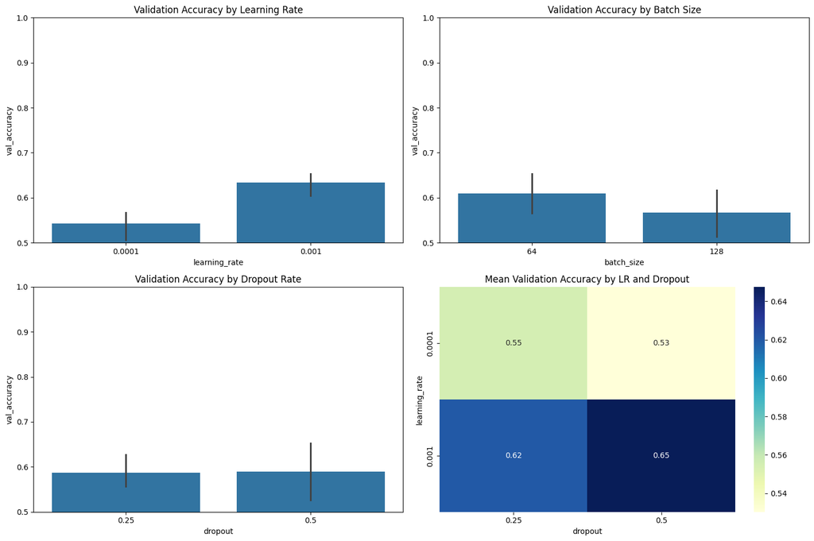

```python
# Convert to DataFrame and visualize results
results_df = pd.DataFrame(results)

# Plot results
plt.figure(figsize=(15, 10))

# Learning rate comparison
plt.subplot(2, 2, 1)
sns.barplot(x='learning_rate', y='val_accuracy', data=results_df)
plt.title('Validation Accuracy by Learning Rate')
plt.ylim(0.5, 1.0)

# Batch size comparison
plt.subplot(2, 2, 2)
sns.barplot(x='batch_size', y='val_accuracy', data=results_df)
plt.title('Validation Accuracy by Batch Size')
plt.ylim(0.5, 1.0)

# Dropout comparison
plt.subplot(2, 2, 3)
sns.barplot(x='dropout', y='val_accuracy', data=results_df)
plt.title('Validation Accuracy by Dropout Rate')
plt.ylim(0.5, 1.0)

# Combined parameter heatmap
plt.subplot(2, 2, 4)
pivot_table = results_df.pivot_table(
    index='learning_rate',
    columns='dropout',
    values='val_accuracy',
    aggfunc='mean'
)
sns.heatmap(pivot_table, annot=True, cmap='YlGnBu')
plt.title('Mean Validation Accuracy by LR and Dropout')

plt.tight_layout()
plt.show()
```

### Hyparameter Tuned CNN Model

```python
randomSeedClear()

ht_cnn_model = Sequential([
        Conv2D(32, (3, 3), activation='relu', padding='same', input_shape=(32,32,3)),
        MaxPooling2D((2, 2)),

        Conv2D(64, (3, 3), activation='relu', padding='same'),
        MaxPooling2D((2, 2)),

        Flatten(),
        Dense(64, activation='relu'),
        Dropout(best_params['dropout']),
        Dense(10, activation='softmax')
    ])

ht_cnn_model.compile(
    optimizer=Adam(learning_rate=best_params['learning_rate']),
    loss='categorical_crossentropy',
    metrics=['accuracy',tf.keras.metrics.Precision(), tf.keras.metrics.Recall(), tf.keras.metrics.AUC()]
)

print("Hyparparameter Tuned CNN Model Summary:")
ht_cnn_model.summary()
```

```
Hyparparameter Tuned CNN Model Summary:
```

```
Model: "sequential"
```

```
┏━━━━━━━━━━━━━━━━━━━━━━━━━━━━━━━━━┳━━━━━━━━━━━━━━━━━━━━━━━━┳━━━━━━━━━━━━━━━┓
┃ Layer (type)                    ┃ Output Shape           ┃       Param # ┃
┡━━━━━━━━━━━━━━━━━━━━━━━━━━━━━━━━━╇━━━━━━━━━━━━━━━━━━━━━━━━╇━━━━━━━━━━━━━━━┩
│ conv2d (Conv2D)                 │ (None, 32, 32, 32)     │           896 │
├─────────────────────────────────┼────────────────────────┼───────────────┤
│ max_pooling2d (MaxPooling2D)    │ (None, 16, 16, 32)     │             0 │
├─────────────────────────────────┼────────────────────────┼───────────────┤
│ conv2d_1 (Conv2D)               │ (None, 16, 16, 64)     │        18,496 │
├─────────────────────────────────┼────────────────────────┼───────────────┤
│ max_pooling2d_1 (MaxPooling2D)  │ (None, 8, 8, 64)       │             0 │
├─────────────────────────────────┼────────────────────────┼───────────────┤
│ flatten (Flatten)               │ (None, 4096)           │             0 │
├─────────────────────────────────┼────────────────────────┼───────────────┤
│ dense (Dense)                   │ (None, 64)             │       262,208 │
├─────────────────────────────────┼────────────────────────┼───────────────┤
│ dropout (Dropout)               │ (None, 64)             │             0 │
├─────────────────────────────────┼────────────────────────┼───────────────┤
│ dense_1 (Dense)                 │ (None, 10)             │           650 │
└─────────────────────────────────┴────────────────────────┴───────────────┘
```

```
 Total params: 282,250 (1.08 MB)
```

```
 Trainable params: 282,250 (1.08 MB)
```

```
 Non-trainable params: 0 (0.00 B)
```